# HW 2

2023-01-12

Let’s begin by loading in the data.

```r
library(tidyverse)
```

```r
# Set our ggplot theme from the outset
theme_set(theme_light())
# Read in the data
gender_employment <- read_csv("../Data/gender_employment.csv")
# look at the raw data
glimpse(gender_employment)
```

```
## Rows: 2,088
## Columns: 12
## $ year                  <dbl> 2013, 2013, 2013, 2013, 2013, 2013, 2013, 2013, …
## $ occupation            <chr> "Chief executives", "General and operations mana…
## $ major_category        <chr> "Management, Business, and Financial", "Manageme…
## $ minor_category        <chr> "Management", "Management", "Management", "Manag…
## $ total_workers         <dbl> 1024259, 977284, 14815, 43015, 754514, 44198, 10…
## $ workers_male          <dbl> 782400, 681627, 8375, 17775, 440078, 16141, 7287…
## $ workers_female        <dbl> 241859, 295657, 6440, 25240, 314436, 28057, 3683…
## $ percent_female        <dbl> 23.6, 30.3, 43.5, 58.7, 41.7, 63.5, 33.6, 27.5, …
## $ total_earnings        <dbl> 120254, 73557, 67155, 61371, 78455, 74114, 62187…
## $ total_earnings_male   <dbl> 126142, 81041, 71530, 75190, 91998, 90071, 66579…
## $ total_earnings_female <dbl> 95921, 60759, 65325, 55860, 65040, 66052, 55079,…
## $ wage_percent_of_male  <dbl> 76.04208, 74.97316, 91.32532, 74.29179, 70.69719…
```

Now lets visualize the data in respect to the trend we will be looking at.

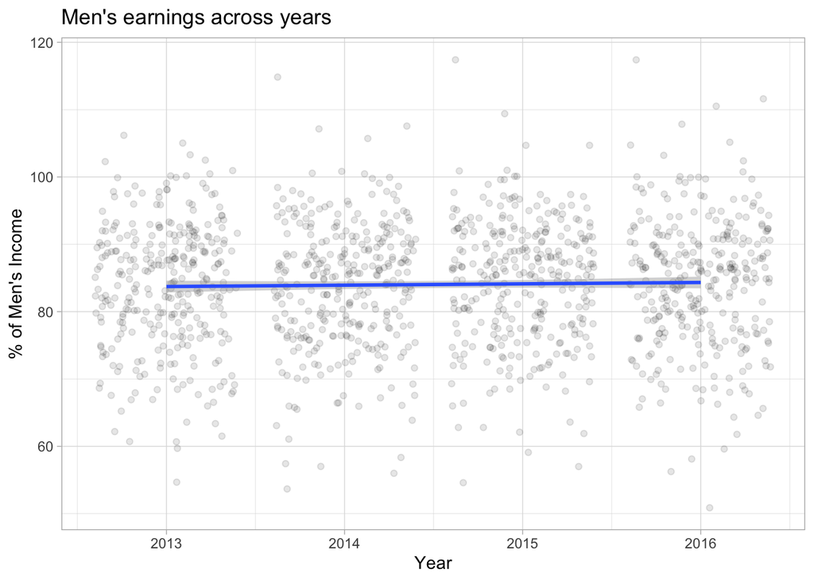

```r
gender_employment %>%
  ggplot(aes(x = year, y = wage_percent_of_male)) +
  geom_jitter(alpha = 0.1) +
  geom_smooth(method = "lm") +
  labs(title = "Men's earnings across years",
       y = "% of Men's Income",
       x = "Year")
```

# Question 1

```r
# first let's relevel our categorical variable
gender_employment <- gender_employment %>%
  mutate(major_category = as.factor(major_category),
         major_category = relevel(major_category, ref = "Management, Business, and Financial"))

# next, let's create our model
parallel_model <- lm(wage_percent_of_male ~ major_category + year, data = gender_employment)

# lastly, let's summarize the data
library(broom)
tidy(parallel_model)
```

```
## # A tibble: 9 × 5
##   term                                         estimate std.e…¹ stati…²  p.value
##   <chr>                                           <dbl>   <dbl>   <dbl>    <dbl>
## 1 (Intercept)                                  -307.    459.     -0.669 5.04e- 1
## 2 major_categoryComputer, Engineering, and Sc…    6.32    0.946   6.68  3.56e-11
## 3 major_categoryEducation, Legal, Community S…    5.76    0.985   5.84  6.53e- 9
## 4 major_categoryHealthcare Practitioners and …    5.52    1.10    5.00  6.41e- 7
## 5 major_categoryNatural Resources, Constructi…    4.91    1.24    3.95  8.15e- 5
## 6 major_categoryProduction, Transportation, a…   -1.31    0.960  -1.37  1.72e- 1
## 7 major_categorySales and Office                  3.33    0.858   3.88  1.11e- 4
## 8 major_categoryService                           6.08    0.885   6.87  1.03e-11
## 9 year                                            0.192   0.228   0.844 3.99e- 1
## # … with abbreviated variable names ¹std.error, ²statistic
```

**Can we say anything about overall trends by year?** Each year, the male’s wage goes up, on average, by 0.19 units.

**1. Calculate the wage percentage of male income for Sales and Office occupations in 2015.**
$$-306.72 + 3.33 * 1 + 0.19 * 2015 =
79.46$$
(I decided to use the actual year in the year category because in question 3 they replace year with the actual year.

MY INTERPRETATION: Sales and Office Occupations male’s income percentage will increase in 2015 by 79.46 units.  
**2. Calculate the wage percentage of male income for Service occupations in 2016.**

$$-306.72 + 6.08 * 1 + 0.19 * 2016
= 82.4$$

MY INTERPRETATION: Service male’s income percentage will increase by 82.4 units in 2016.

# Question 2

Next, let’s create a similar plot as above but separate the plots by major category.

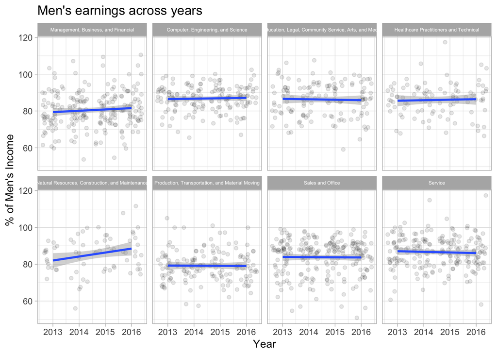

```r
gender_employment%>%
  ggplot(aes(x = year, y = wage_percent_of_male)) +
  geom_jitter(alpha = 0.1) +
  geom_smooth(method = "lm") +
  labs(title = "Men's earnings across years",
       y = "% of Men's Income",
       x = "Year") +
  facet_wrap(~major_category, nrow = 2) + theme(strip.text.x = element_text(size = 5))
```

# Question 3

Based on this observation, now let’s try fitting the model as an interaction.

```r
interaction_model <- lm(wage_percent_of_male ~ major_category * year, data = gender_employment)

# lastly, let's summarize the data
library(broom)
tidy(interaction_model)
```

```
## # A tibble: 16 × 5
##    term                                         estimate std.e…¹ stati…² p.value
##    <chr>                                           <dbl>   <dbl>   <dbl>   <dbl>
##  1 (Intercept)                                  -1.37e+3 1.11e+3  -1.24    0.216
##  2 major_categoryComputer, Engineering, and Sc…  1.00e+3 1.70e+3   0.589   0.556
##  3 major_categoryEducation, Legal, Community S…  1.94e+3 1.77e+3   1.09    0.275
##  4 major_categoryHealthcare Practitioners and …  9.06e+2 1.99e+3   0.456   0.649
##  5 major_categoryNatural Resources, Constructi… -2.89e+3 2.23e+3  -1.29    0.196
##  6 major_categoryProduction, Transportation, a…  1.58e+3 1.73e+3   0.909   0.363
##  7 major_categorySales and Office                1.61e+3 1.54e+3   1.05    0.296
##  8 major_categoryService                         2.14e+3 1.59e+3   1.34    0.180
##  9 year                                          7.20e-1 5.49e-1   1.31    0.190
## 10 major_categoryComputer, Engineering, and Sc… -4.95e-1 8.45e-1  -0.585   0.559
## 11 major_categoryEducation, Legal, Community S… -9.59e-1 8.80e-1  -1.09    0.276
## 12 major_categoryHealthcare Practitioners and … -4.47e-1 9.86e-1  -0.453   0.651
## 13 major_categoryNatural Resources, Constructi…  1.44e+0 1.11e+0   1.30    0.195
## 14 major_categoryProduction, Transportation, a… -7.84e-1 8.61e-1  -0.910   0.363
## 15 major_categorySales and Office:year          -7.98e-1 7.65e-1  -1.04    0.297
## 16 major_categoryService:year                   -1.06e+0 7.92e-1  -1.34    0.182
## # … with abbreviated variable names ¹std.error, ²statistic
```

**What about for Service?**

$$-1370.47 + 0.72*2016 + 2137.65 * 1 -
1.06 * 2016 * 1= 81.74$$
The estimate for the male wage percentage in service for 2016 is 81.74%.

I notice that the estimates for each are not as close as they were when we used the parallel model. I am wondering if this has something to do with the fact that with an interaction model we are able to allow for different slopes and lines, so that the model can make estimates that are farther apart.

# Question 4

**Why would we choose to build a model that assumes parallel trends?**  
The parallel model is easier, and interaction models are more complex. When the complexity is not warranted, there is no reason to use such a complicated model like an interaction. For example, when the slopes seem not to differ as much, then adding the complexity of an interaction model makes no sense.

# Question 5

We will start by building a simple model where `wage_percent_of_male` is the outcome variable and `year` is the predictor.

```r
# we already looked at the raw data above, but before we build our model
# lets look at a summary of the raw data

summary(gender_employment %>%
  select(year, wage_percent_of_male))
```

```
##       year      wage_percent_of_male
##  Min.   :2013   Min.   : 50.88
##  1st Qu.:2014   1st Qu.: 77.56
##  Median :2014   Median : 85.16
##  Mean   :2014   Mean   : 84.03
##  3rd Qu.:2015   3rd Qu.: 90.62
##  Max.   :2016   Max.   :117.40
##                 NA's   :846
```

```r
# build model
simple_fit <- lm(wage_percent_of_male ~ year, data = gender_employment)

# summarize
tidy(simple_fit)
```

```
## # A tibble: 2 × 5
##   term        estimate std.error statistic p.value
##   <chr>          <dbl>     <dbl>     <dbl>   <dbl>
## 1 (Intercept) -322.      479.       -0.671   0.502
## 2 year           0.201     0.238     0.847   0.397
```

For each additional year, there is a .20 unit increase men’s income percentage.

```r
# now lets fine the correlations
gender_employment %>%
  select(year, wage_percent_of_male, percent_female) %>%
  cor(use = "complete.obs")
```

```
##                             year wage_percent_of_male percent_female
## year                 1.000000000           0.02403895    0.004998286
## wage_percent_of_male 0.024038950           1.00000000    0.111464461
## percent_female       0.004998286           0.11146446    1.000000000
```

Now we have the correlation coefficients between year, percent of men’s income, and percent of females.

We see pretty weak correlations between the variables (0.02, 0.005, 0.11).

Now that we see there is weak correlation however, we really want to see if the relationship between `year` and the paygap are conditional on the proportion of women who work in an occupation. To do this we will add proportion of women who work in an occupation to our linear model.

```r
# again, before creating the model let's look at a summary
summary(gender_employment %>%
  select(year, wage_percent_of_male, percent_female))
```

```
##       year      wage_percent_of_male percent_female
##  Min.   :2013   Min.   : 50.88       Min.   :  0.00
##  1st Qu.:2014   1st Qu.: 77.56       1st Qu.: 10.73
##  Median :2014   Median : 85.16       Median : 32.40
##  Mean   :2014   Mean   : 84.03       Mean   : 36.00
##  3rd Qu.:2015   3rd Qu.: 90.62       3rd Qu.: 57.31
##  Max.   :2016   Max.   :117.40       Max.   :100.00
##                 NA's   :846
```

```r
# create the model
multiple_fit <- lm(wage_percent_of_male ~ year + percent_female, data = gender_employment)

# summarize
tidy(multiple_fit)
```

```
## # A tibble: 3 × 5
##   term            estimate std.error statistic   p.value
##   <chr>              <dbl>     <dbl>     <dbl>     <dbl>
## 1 (Intercept)    -314.      477.        -0.660 0.510
## 2 year              0.197     0.237      0.832 0.406
## 3 percent_female    0.0425    0.0108     3.94  0.0000843
```

# Question 6

**Briefly tell me, in your own words, what R-squared is.** R-squared has to do with variation in the dependent variable around the mean that is explained by the model. In other words, the R-squared value shows you the variation around the regression line.

```r
# let's look at the r-squared value for the model without the condition
simple_glanced <- glance(simple_fit)
simple_glanced$r.squared
```

```
## [1] 0.0005778711
```

```r
# let's look at the r-squared value for the model with the condition
multiple_glanced <- glance(multiple_fit)
multiple_glanced$r.squared
```

```
## [1] 0.01297574
```

The simple model has an r-squared value of 0.05% and the r-squared value for the multiple variable models is 1.30%.